# Topic: credit score classification

# TRANSFORMATION

[figure not shown]

```python
df5['Delay_from_due_date_log']=np.log(df5['Delay_from_due_date'])
df5['Delay_from_due_date_sqrt']=np.sqrt(df5['Delay_from_due_date'])
plt.hist(df5['Delay_from_due_date']);
```

Insight:

```
This plot is followed by approximately normal distribution.
```

# OUTLIER IDENTIFICATION:

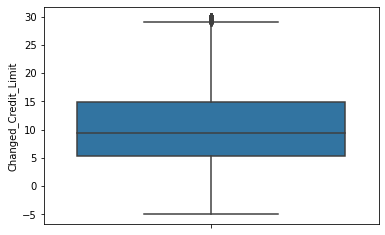

```python
sns.boxplot(y='Changed_Credit_Limit',data=df)
```

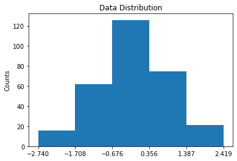

```python
import numpy as np
import matplotlib.pyplot as plt

# Generate random data
data = np.random.normal(loc=0, scale=1, size=300)

# Set the number of bins for the bar plot
num_bins = 5

# Create the histogram using numpy's histogram function
counts, bins, _ = plt.hist(data, bins=num_bins)

# Set the x-axis labels as the bin edges
plt.xticks(bins)

# Set the y-axis label
plt.ylabel('Counts')

# Set the plot title
plt.title('Data Distribution')

# Display the plot
plt.show()
```

Insight:

```
This plot is followed by approximately normal distribution.
```

# OUTLIER DETECTION:

```python
# IQR method for identifying outliers
df6=df.copy()
IQR  = df6['Changed_Credit_Limit'].quantile(0.75)- df6['Changed_Credit_Limit'].quantile(0.25)
upper = df6['Changed_Credit_Limit'].quantile(0.75) + (1.5*IQR)
lower = df6['Changed_Credit_Limit'].quantile(0.25) - (1.5*IQR)
df6[(df6['Changed_Credit_Limit']> upper) | (df6['Changed_Credit_Limit']<lower)].shape[0]
```

```
522
```

```python
# Capping outliers
max1=df6['Changed_Credit_Limit'].quantile(0.95)
min1=df6['Changed_Credit_Limit'].quantile(0.05)
df6['Changed_Credit_Limit']=np.clip(df6['Changed_Credit_Limit'],min1,max1)
```

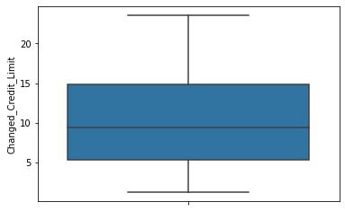

```python
sns.boxplot(y='Changed_Credit_Limit',data=df6)
```

# TRANSFORMATION

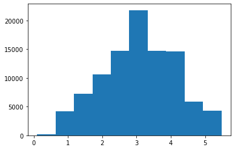

```python
plt.hist(df6['Changed_Credit_Limit_sqrt'])
```

Insight:

```
This plot is followed by approximately normal distribution.
```

# OULIER IDENTIFICATION:

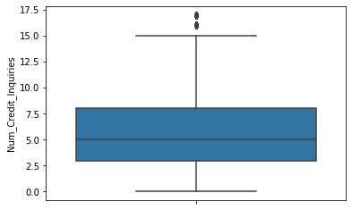

```python
sns.boxplot(y='Num_Credit_Inquiries',data=df)
```

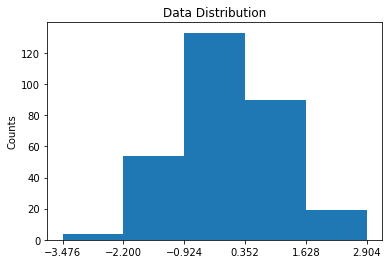

```python
import numpy as np
import matplotlib.pyplot as plt

# Generate random data
data = np.random.normal(loc=0, scale=1, size=300)

# Set the number of bins for the bar plot
num_bins = 5

# Create the histogram using numpy's histogram function
counts, bins, _ = plt.hist(data, bins=num_bins)

# Set the x-axis labels as the bin edges
plt.xticks(bins)

# Set the y-axis label
plt.ylabel('Counts')

# Set the plot title
plt.title('Data Distribution')

# Display the plot
plt.show()
```

Insight:

```
This plot is followed by approximately normal distribution.
```

# OUTLIER DETECTION:

```python
# IQR method for identifying outliers
df7=df.copy()
IQR  = df1['Num_Credit_Inquiries'].quantile(0.75)- df1['Num_Credit_Inquiries'].quantile(0.25)
upper = df1['Num_Credit_Inquiries'].quantile(0.75) + (1.5*IQR)
lower = df1['Num_Credit_Inquiries'].quantile(0.25) - (1.5*IQR)
df1[(df1['Num_Credit_Inquiries']> upper) | (df1['Num_Credit_Inquiries']<lower)].shape[0]
```

```
770
```

```python
# Capping outliers
max1=df7['Num_Credit_Inquiries'].quantile(0.95)
min1=df7['Num_Credit_Inquiries'].quantile(0.05)
df7['Num_Credit_Inquiries']=np.clip(df7['Num_Credit_Inquiries'],min1,max1)
```

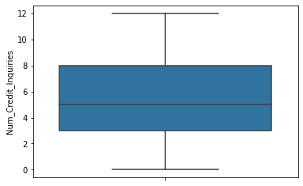

```python
sns.boxplot(y='Num_Credit_Inquiries',data=df7)
```

# TRANSFORMATION

Insight:

```
This plot is followed by approximately normal distribution.
```

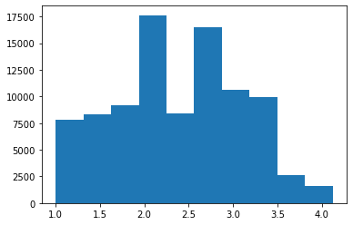

```python
plt.hist(df7['Num_Credit_Inquiries_sqrt'])
```

Insight:

[output not shown]

# OULIER IDENTIFICATION:

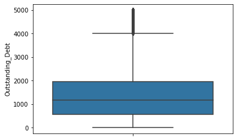

```python
sns.boxplot(y='Outstanding_Debt',data=df)
```

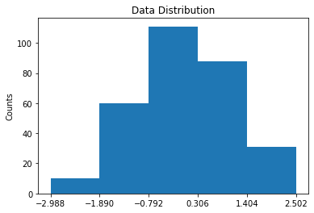

```python
import numpy as np
import matplotlib.pyplot as plt

# Generate random data
data = np.random.normal(loc=0, scale=1, size=300)

# Set the number of bins for the bar plot
num_bins = 5

# Create the histogram using numpy's histogram function
counts, bins, _ = plt.hist(data, bins=num_bins)

# Set the x-axis labels as the bin edges
plt.xticks(bins)

# Set the y-axis label
plt.ylabel('Counts')

# Set the plot title
plt.title('Data Distribution')

# Display the plot
plt.show()
```

Insight:

This plot is followed by approximately normal distribution.

```python
# zscore method
df8=df.copy()
upper=df8['Outstanding_Debt'].mean()+(3*df8['Outstanding_Debt'].std())
lower=df8['Outstanding_Debt'].mean()-(3*df8['Outstanding_Debt'].std())
df3[(df8['Outstanding_Debt']>upper)|(df8['Outstanding_Debt']<lower)].shape[0]
```

```
584
```

```python
# Capping outliers
max1=df8['Outstanding_Debt'].quantile(0.90)
min1=df8['Outstanding_Debt'].quantile(0.10)
df8['Outstanding_Debt']=np.clip(df8['Outstanding_Debt'],min1,max1)
```

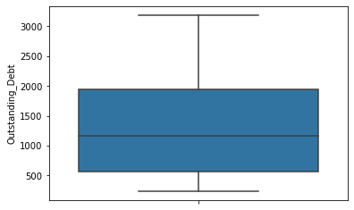

```python
sns.boxplot(y='Outstanding_Debt',data=df8)
```

# TRANSFORMATION

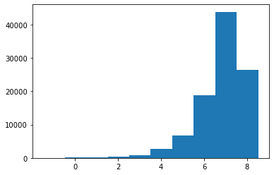

```python
df8=df1.copy()
df8['Outstanding_Debt']=np.log(df8['Outstanding_Debt'])
plt.hist(df8['Outstanding_Debt'])
```

Insight:

[output not shown]

# OULIER IDENTIFICATION:

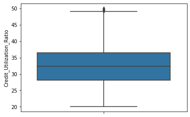

```python
sns.boxplot(y='Credit_Utilization_Ratio',data=df)
```

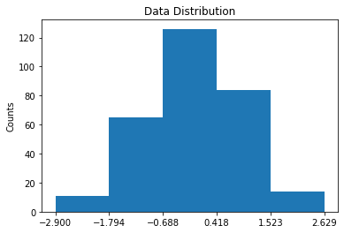

```python
import numpy as np
import matplotlib.pyplot as plt

# Generate random data
data = np.random.normal(loc=0, scale=1, size=300)

# Set the number of bins for the bar plot
num_bins = 5

# Create the histogram using numpy's histogram function
counts, bins, _ = plt.hist(data, bins=num_bins)

# Set the x-axis labels as the bin edges
plt.xticks(bins)

# Set the y-axis label
plt.ylabel('Counts')

# Set the plot title
plt.title('Data Distribution')

# Display the plot
plt.show()
```

Insight:

This plot is followed by approximately normal distribution.

```python
# zscore method
df9=df.copy()
upper=df9['Credit_Utilization_Ratio'].mean()+(3*df9['Credit_Utilization_Ratio'].std())
lower=df9['Credit_Utilization_Ratio'].mean()-(3*df9['Credit_Utilization_Ratio'].std())
df3[(df9['Credit_Utilization_Ratio']>upper)|(df9['Credit_Utilization_Ratio']<lower)].shape[0]
```

```
16
```

```python
# Capping outliers
max1=df9['Credit_Utilization_Ratio'].quantile(0.90)
min1=df9['Credit_Utilization_Ratio'].quantile(0.10)
df9['Credit_Utilization_Ratio']=np.clip(df9['Credit_Utilization_Ratio'],min1,max1)
```

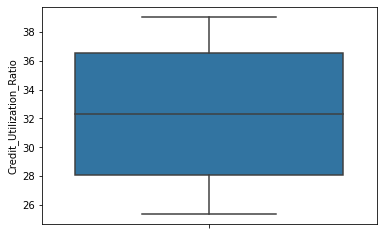

```python
sns.boxplot(y='Credit_Utilization_Ratio',data=df9)
```

# TRANSFORMATION

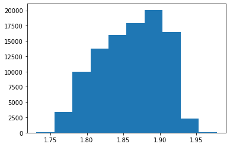

```python
plt.hist(df9['Credit_Utilization_Ratio_sqrt'])
```

Insight:

This plot is followed by approximately normal distribution.

# OULIER IDENTIFICATION:

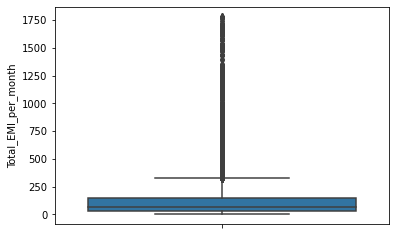

```python
sns.boxplot(y='Total_EMI_per_month',data=df)
```

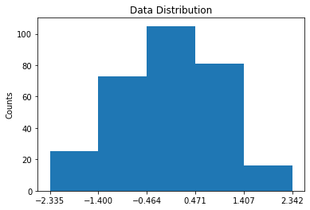

```python
import numpy as np
import matplotlib.pyplot as plt

# Generate random data
data = np.random.normal(loc=0, scale=1, size=300)

# Set the number of bins for the bar plot
num_bins = 5

# Create the histogram using numpy's histogram function
counts, bins, _ = plt.hist(data, bins=num_bins)

# Set the x-axis labels as the bin edges
plt.xticks(bins)

# Set the y-axis label
plt.ylabel('Counts')

# Set the plot title
plt.title('Data Distribution')

# Display the plot
plt.show()
```

Insight:

This plot is followed by approximately normal distribution.

```python
# zscore method
df10=df.copy()
upper=df10['Total_EMI_per_month'].mean()+(3*df10['Total_EMI_per_month'].std())
lower=df10['Total_EMI_per_month'].mean()-(3*df10['Total_EMI_per_month'].std())
df3[(df10['Total_EMI_per_month']>upper)|(df10['Total_EMI_per_month']<lower)].shape[0]
```

```
1344
```

```python
# Capping outliers
max1=df10['Total_EMI_per_month'].quantile(0.90)
min1=df10['Total_EMI_per_month'].quantile(0.10)
df10['Total_EMI_per_month']=np.clip(df10['Total_EMI_per_month'],min1,max1)
```

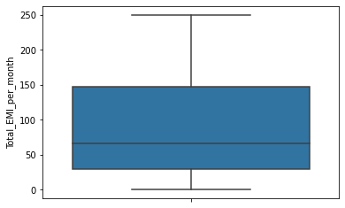

```python
sns.boxplot(y='Total_EMI_per_month',data=df10)
```

Insight:

```
From above the boxplot after treatment using z score method then outlier clear.
```

# TRANSFORMATION

[figure not shown]

```python
df10['Total_EMI_per_month_log']=np.log(df10['Total_EMI_per_month'])
df10['Total_EMI_per_month_sqrt']=np.sqrt(df10['Total_EMI_per_month'])
plt.hist(df10['Total_EMI_per_month']);
```

Insight:

From the plot we can consider that the Total_EMI_per_month aproximately normal distribution. which can consider for the analysis and hence log root methods bring the data into flow by normal distribution.

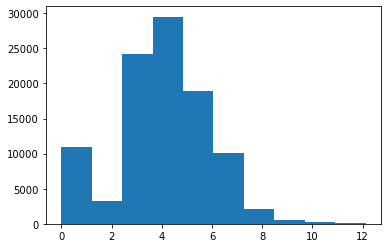

```python
import numpy as np
import matplotlib.pyplot as plt

df10 = df1.copy()
df10['Total_EMI_per_month_cbrt'] = np.cbrt(df10['Total_EMI_per_month'])
plt.hist(df10['Total_EMI_per_month_cbrt'])
plt.show()
```

# OULIER IDENTIFICATION:

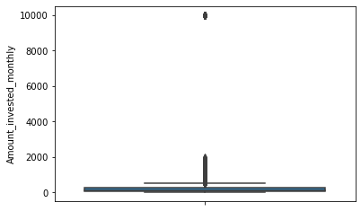

```python
sns.boxplot(y='Amount_invested_monthly',data=df)
```

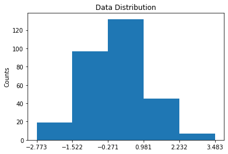

```python
import numpy as np
import matplotlib.pyplot as plt

# Generate random data
data = np.random.normal(loc=0, scale=1, size=300)

# Set the number of bins for the bar plot
num_bins = 5

# Create the histogram using numpy's histogram function
counts, bins, _ = plt.hist(data, bins=num_bins)

# Set the x-axis labels as the bin edges
plt.xticks(bins)

# Set the y-axis label
plt.ylabel('Counts')

# Set the plot title
plt.title('Data Distribution')

# Display the plot
plt.show()
```

Insight:

This plot is followed by approximately normal distribution.

```python
# zscore method
df11=df.copy()
upper=df11['Amount_invested_monthly'].mean()+(3*df11['Amount_invested_monthly'].std())
lower=df11['Amount_invested_monthly'].mean()-(3*df11['Amount_invested_monthly'].std())
df11[(df11['Amount_invested_monthly']>upper)|(df11['Amount_invested_monthly']<lower)].shape[0]
```

```
4471
```

```python
# Capping outliers
max1=df11['Amount_invested_monthly'].quantile(0.90)
min1=df11['Amount_invested_monthly'].quantile(0.10)
df11['Amount_invested_monthly']=np.clip(df11['Amount_invested_monthly'],min1,max1)
```

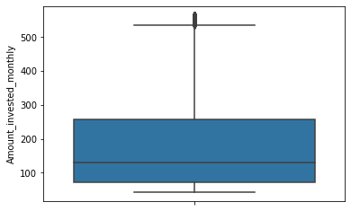

```python
sns.boxplot(y='Amount_invested_monthly',data=df11)
```

# TRANSFORMATION

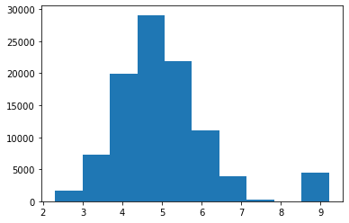

```python
import numpy as np
import matplotlib.pyplot as plt

df11 = df1.copy()
positive_values = df11['Amount_invested_monthly'] > 0  # Filter positive values
df11 = df11[positive_values]

df11['Amount_invested_monthly'] = np.log(df11['Amount_invested_monthly'])
plt.hist(df11['Amount_invested_monthly'])
plt.show()
```

Insight:

This plot is followed by approximately normal distribution.

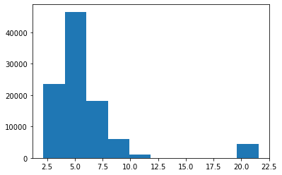

```python
import numpy as np
import matplotlib.pyplot as plt

df11 = df1.copy()

# Filter out non-positive values
positive_values = df11['Amount_invested_monthly'] > 0
df11 = df11[positive_values]

# Apply transformations
df11['Amount_invested_monthly_cbrt'] = np.cbrt(df11['Amount_invested_monthly'])

# Plot histogram
plt.hist(df11['Amount_invested_monthly_cbrt'])
plt.show()
```

Insight:

[output not shown]

# OULIER IDENTIFICATION:

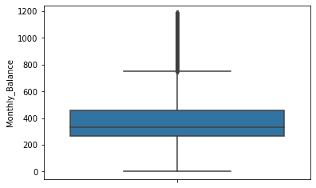

```python
sns.boxplot(y='Monthly_Balance',data=df)
```

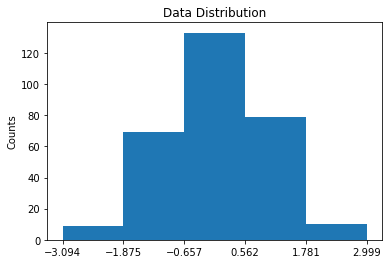

```python
import numpy as np
import matplotlib.pyplot as plt

# Generate random data
data = np.random.normal(loc=0, scale=1, size=300)

# Set the number of bins for the bar plot
num_bins = 5

# Create the histogram using numpy's histogram function
counts, bins, _ = plt.hist(data, bins=num_bins)

# Set the x-axis labels as the bin edges
plt.xticks(bins)

# Set the y-axis label
plt.ylabel('Counts')

# Set the plot title
plt.title('Data Distribution')

# Display the plot
plt.show()
```

Insight:

This plot is followed by approximately normal distribution.

```python
# zscore method
df12=df.copy()
upper=df12['Monthly_Balance'].mean()+(3*df12['Monthly_Balance'].std())
lower=df12['Monthly_Balance'].mean()-(3*df12['Monthly_Balance'].std())
df12[(df12['Monthly_Balance']>upper)|(df12['Monthly_Balance']<lower)].shape[0]
```

```
1585
```

```python
# Capping outliers
max1=df12['Monthly_Balance'].quantile(0.95)
min1=df12['Monthly_Balance'].quantile(0.05)
df12['Monthly_Balance']=np.clip(df12['Monthly_Balance'],min1,max1)
```

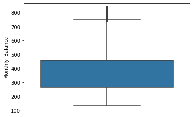

```python
sns.boxplot(y='Monthly_Balance',data=df12)
```

# TRANSFORMATION

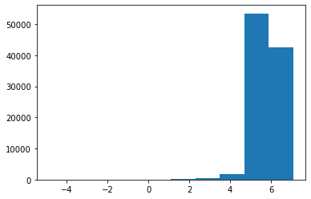

```python
import numpy as np
import matplotlib.pyplot as plt

df12 = df1.copy()

# Filter out non-positive values
positive_values = df12['Monthly_Balance'] > 0
df12 = df12[positive_values]

# Apply transformations
df12['Monthly_Balance'] = np.log(df12['Monthly_Balance'])

# Plot histogram
plt.hist(df12['Monthly_Balance'])
plt.show()
```

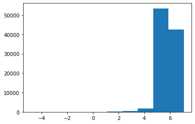

```python
df12['Monthly_Balance_log']=np.log(df12['Monthly_Balance'])
df12['Monthly_Balance_sqrt']=np.sqrt(df12['Monthly_Balance'])
plt.hist(df12['Monthly_Balance']);
```

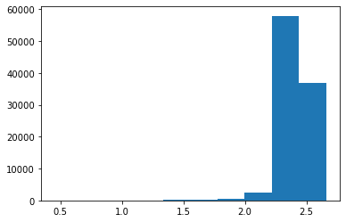

```python
plt.hist(df12['Monthly_Balance_sqrt'])
```

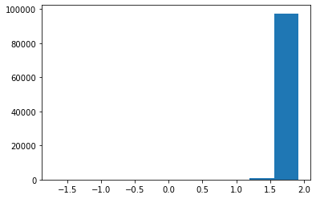

```python
df12['Monthly_Balance_cbrt'] = np.cbrt(df12['Monthly_Balance'])
plt.hist(df12['Monthly_Balance_cbrt'])
```

```python
df.isnull().sum()
```

```
ID                          0
Customer_ID                 0
Month                       0
Name                        0
Age                         0
SSN                         0
Occupation                  0
Annual_Income               0
Monthly_Inhand_Salary       0
Num_Bank_Accounts           0
Num_Credit_Card             0
Interest_Rate               0
Num_of_Loan                 0
Type_of_Loan                0
Delay_from_due_date         0
Num_of_Delayed_Payment      0
Changed_Credit_Limit        0
Num_Credit_Inquiries        0
Credit_Mix                  0
Outstanding_Debt            0
Credit_Utilization_Ratio    0
Credit_History_Age          0
Payment_of_Min_Amount       0
Total_EMI_per_month         0
Amount_invested_monthly     0
Payment_Behaviour           0
Monthly_Balance             0
Credit_Score                0
dtype: int64
```

```python
df[df['Credit_Score'].isna()].info()
```

```
<class 'pandas.core.frame.DataFrame'>
Index: 0 entries
Data columns (total 28 columns):
 #   Column                    Non-Null Count  Dtype
---  ------                    --------------  -----
 0   ID                        0 non-null      int64
 1   Customer_ID               0 non-null      int64
 2   Month                     0 non-null      int64
 3   Name                      0 non-null      object
 4   Age                       0 non-null      int64
 5   SSN                       0 non-null      int64
 6   Occupation                0 non-null      object
 7   Annual_Income             0 non-null      float64
 8   Monthly_Inhand_Salary     0 non-null      float64
 9   Num_Bank_Accounts         0 non-null      int64
```

[output cut: 20 more lines]

# LABEL ENCODING

```python
from sklearn.preprocessing import LabelEncoder
le = LabelEncoder()
for i in ['Name','Occupation','Num_of_Loan','Type_of_Loan','Credit_Mix','Payment_of_Min_Amount','Payment_Behaviour','Credit_Score']:
    df[i]=le.fit_transform(df[i].values.reshape(-1,1))
```

```python
df.head()
```

|  | ID | Customer_ID | Month | Name | Age | SSN | Occupation | Annual_Income | Monthly_Inhand_Salary | Num_Bank_Accounts | ... | Credit_Mix | Outstanding_Debt | Credit_Utilization_Ratio | Credit_History_Age | Payment_of_Min_Amount | Total_EMI_per_month | Amount_invested_monthly | Payment_Behaviour | Monthly_Balance | Credit_Score |
| --- | --- | --- | --- | --- | --- | --- | --- | --- | --- | --- | --- | --- | --- | --- | --- | --- | --- | --- | --- | --- | --- |
| 0 | 5634 | 3392 | 1 | 84 | 23 | 821000265 | 12 | 19114.12 | 1824.843333 | 3 | ... | 3 | 809.98 | 26.822620 | 182 | 1 | 49.574949 | 80.415295 | 3 | 312.494089 | 0 |
| 1 | 5635 | 3392 | 2 | 84 | 23 | 821000265 | 12 | 19114.12 | 1824.843333 | 3 | ... | 1 | 809.98 | 31.944960 | 183 | 1 | 49.574949 | 118.280222 | 4 | 284.629163 | 0 |
| 2 | 5636 | 3392 | 3 | 84 | 23 | 821000265 | 12 | 19114.12 | 1824.843333 | 3 | ... | 1 | 809.98 | 28.609352 | 184 | 1 | 49.574949 | 81.699521 | 5 | 331.209863 | 0 |
| 3 | 5637 | 3392 | 4 | 84 | 23 | 821000265 | 12 | 19114.12 | 1824.843333 | 3 | ... | 1 | 809.98 | 31.377862 | 185 | 1 | 49.574949 | 199.458074 | 6 | 223.451310 | 0 |
| 4 | 5638 | 3392 | 5 | 84 | 23 | 821000265 | 12 | 19114.12 | 1824.843333 | 3 | ... | 1 | 809.98 | 24.797347 | 186 | 1 | 49.574949 | 41.420153 | 2 | 341.489231 | 0 |

5 rows × 28 columns

Insight:

[output not shown]

# Scaling

```python
from sklearn.preprocessing import StandardScaler
sc = StandardScaler()
for i in ['ID','Customer_ID','Month','Age','SSN','Annual_Income','Monthly_Inhand_Salary','Num_Bank_Accounts','Num_Credit_Card','Interest_Rate','Delay_from_due_date','Num_of_Delayed_Payment','Changed_Credit_Limit','Outstanding_Debt','Credit_Utilization_Ratio','Credit_Utilization_Ratio','Credit_History_Age','Total_EMI_per_month','Amount_invested_monthly','Monthly_Balance']:
    df[i] = sc.fit_transform(df[i].values.reshape(-1,1))
df
```

|  | ID | Customer_ID | Month | Name | Age | SSN | Occupation | Annual_Income | Monthly_Inhand_Salary | Num_Bank_Accounts | ... | Credit_Mix | Outstanding_Debt | Credit_Utilization_Ratio | Credit_History_Age | Payment_of_Min_Amount | Total_EMI_per_month | Amount_invested_monthly | Payment_Behaviour | Monthly_Balance | Credit_Score |
| --- | --- | --- | --- | --- | --- | --- | --- | --- | --- | --- | --- | --- | --- | --- | --- | --- | --- | --- | --- | --- | --- |
| 0 | -1.732555 | -1.575254 | -1.527525 | 84 | -0.957734 | 1.102061 | 12 | -0.819559 | -0.744572 | -0.913294 | ... | 3 | -0.533642 | -1.067459 | -0.393259 | 1 | -0.439329 | -0.269106 | 3 | -0.361544 | 0 |
| 1 | -1.732532 | -1.575254 | -1.091089 | 84 | -0.957734 | 1.102061 | 12 | -0.819559 | -0.744572 | -0.913294 | ... | 1 | -0.533642 | -0.066397 | -0.383227 | 1 | -0.439329 | -0.250516 | 4 | -0.496617 | 0 |
| 2 | -1.732509 | -1.575254 | -0.654654 | 84 | -0.957734 | 1.102061 | 12 | -0.819559 | -0.744572 | -0.913294 | ... | 1 | -0.533642 | -0.718277 | -0.373195 | 1 | -0.439329 | -0.268476 | 5 | -0.270820 | 0 |
| 3 | -1.732486 | -1.575254 | -0.218218 | 84 | -0.957734 | 1.102061 | 12 | -0.819559 | -0.744572 | -0.913294 | ... | 1 | -0.533642 | -0.177226 | -0.363163 | 1 | -0.439329 | -0.210660 | 6 | -0.793172 | 0 |
| 4 | -1.732462 | -1.575254 | 0.218218 | 84 | -0.957734 | 1.102061 | 12 | -0.819559 | -0.744572 | -0.913294 | ... | 1 | -0.533642 | -1.463259 | -0.353131 | 1 | -0.439329 | -0.288252 | 2 | -0.220992 | 0 |
| ... | ... | ... | ... | ... | ... | ... | ... | ... | ... | ... | ... | ... | ... | ... | ... | ... | ... | ... | ... | ... | ... |
| 99971 | 1.731779 | 0.833310 | -0.218218 | 6528 | -0.771958 | -1.450124 | 9 | -0.283859 | -0.263079 | -0.527728 | ... | 3 | -0.799924 | 0.464902 | 0.078248 | 1 | -0.549090 | -0.278653 | 1 | -1.876337 | 1 |
| 99972 | 1.731803 | 0.833310 | 0.218218 | 6528 | -0.771958 | -1.450124 | 9 | -0.283859 | -0.263079 | -0.527728 | ... | 3 | -0.799924 | 1.618345 | 0.088280 | 1 | -0.549090 | -0.281984 | 2 | -1.876337 | 1 |
| 99973 | 1.731826 | 0.833310 | 0.654654 | 6528 | -0.771958 | -1.450124 | 9 | -0.283859 | -0.263079 | -0.527728 | ... | 1 | -0.799924 | 1.753171 | 0.098312 | 1 | -0.549090 | -0.296790 | 1 | -1.876337 | 1 |
| 99974 | 1.731849 | 0.833310 | 1.091089 | 6528 | -0.771958 | -1.450124 | 9 | -0.283859 | -0.263079 | -0.527728 | ... | 1 | -0.799924 | 0.264515 | 0.108344 | 1 | -0.549090 | -0.185025 | 4 | -1.876337 | 2 |
| 99975 | 1.731872 | 0.833310 | 1.527525 | 6528 | -0.771958 | -1.450124 | 9 | -0.283859 | -0.263079 | -0.527728 | ... | 1 | -0.799924 | 0.372833 | 0.118376 | 1 | -0.549090 | -0.226516 | 0 | -1.876337 | 1 |

99976 rows × 28 columns

Insight:

[output not shown]

```python
# Drop the column:
columns_to_drop = ["ID", "Credit_History_Age", "Payment_of_Min_Amount", "Age", "SSN", "Occupation", "Annual_Income", "Num_Bank_Accounts", "Customer_ID", "Payment_Behaviour", "Amount_invested_monthly", "Credit_Utilization_Ratio", "Type_of_Loan", "Name", "Total_EMI_per_month", "Monthly_Inhand_Salary", "Num_Credit_Inquiries", "Num_of_Loan", "Monthly_Balance"]
df.drop(columns=columns_to_drop, axis=1, inplace=True, errors='ignore')
```

```python
#target variable
df['Credit_Score'].value_counts(normalize=True)
```

```
Credit_Score
2    0.531658
1    0.290020
0    0.178323
Name: proportion, dtype: float64
```

```python
df.drop_duplicates(inplace=True)
df
```

[output not shown]

99976 rows × 28 columns

```python
x=df.drop('Credit_Score',axis=1) #input features
y=df['Credit_Score'] #target variable
```

```python
x.head()
```

|  | ID | Customer_ID | Month | Name | Age | SSN | Occupation | Annual_Income | Monthly_Inhand_Salary | Num_Bank_Accounts | ... | Num_Credit_Inquiries | Credit_Mix | Outstanding_Debt | Credit_Utilization_Ratio | Credit_History_Age | Payment_of_Min_Amount | Total_EMI_per_month | Amount_invested_monthly | Payment_Behaviour | Monthly_Balance |
| --- | --- | --- | --- | --- | --- | --- | --- | --- | --- | --- | --- | --- | --- | --- | --- | --- | --- | --- | --- | --- | --- |
| 0 | -1.732555 | -1.575254 | -1.527525 | 84 | -0.957734 | 1.102061 | 12 | -0.819559 | -0.744572 | -0.913294 | ... | 4 | 3 | -0.533642 | -1.067459 | -0.393259 | 1 | -0.439329 | -0.269106 | 3 | -0.361544 |
| 1 | -1.732532 | -1.575254 | -1.091089 | 84 | -0.957734 | 1.102061 | 12 | -0.819559 | -0.744572 | -0.913294 | ... | 4 | 1 | -0.533642 | -0.066397 | -0.383227 | 1 | -0.439329 | -0.250516 | 4 | -0.496617 |
| 2 | -1.732509 | -1.575254 | -0.654654 | 84 | -0.957734 | 1.102061 | 12 | -0.819559 | -0.744572 | -0.913294 | ... | 4 | 1 | -0.533642 | -0.718277 | -0.373195 | 1 | -0.439329 | -0.268476 | 5 | -0.270820 |
| 3 | -1.732486 | -1.575254 | -0.218218 | 84 | -0.957734 | 1.102061 | 12 | -0.819559 | -0.744572 | -0.913294 | ... | 4 | 1 | -0.533642 | -0.177226 | -0.363163 | 1 | -0.439329 | -0.210660 | 6 | -0.793172 |
| 4 | -1.732462 | -1.575254 | 0.218218 | 84 | -0.957734 | 1.102061 | 12 | -0.819559 | -0.744572 | -0.913294 | ... | 4 | 1 | -0.533642 | -1.463259 | -0.353131 | 1 | -0.439329 | -0.288252 | 2 | -0.220992 |

5 rows × 27 columns

# Machine Learning

Machine learning leverages statistical techniques and algorithms to enable computers to learn from data and make predictions or take actions, leading to automated decision-making and pattern recognition capabilities. It has various applications in diverse fields such as healthcare, finance, and autonomous systems.

# Using alogorithms

LogisticRegression

KNeighborsClassifier

DecisionTreeClassifier

RandomForestClassifier

Navie Bayes alogorithm

AdaBoostClassifier

GradientBoostingClassifier

GradientBoostingClassifier

```python
import pandas as pd
import numpy as np
from sklearn.model_selection import train_test_split
from sklearn.tree import DecisionTreeClassifier
from sklearn.metrics import precision_score,recall_score,accuracy_score,f1_score,plot_confusion_matrix,classification_report,roc_curve,roc_auc_score,cohen_kappa_score
from sklearn.metrics import roc_auc_score,roc_curve
import matplotlib.pyplot as plt
from sklearn import tree
from sklearn.ensemble import BaggingClassifier
from sklearn.ensemble import AdaBoostClassifier
from sklearn.ensemble import GradientBoostingClassifier
from sklearn.ensemble import RandomForestClassifier
from sklearn.metrics import plot_confusion_matrix,accuracy_score,precision_score,f1_score,roc_auc_score,classification_report,confusion_matrix
```

# MODEL BUILDING

```python
xtrain,xtest,ytrain,ytest = train_test_split(x,y,test_size=0.2,stratify=y,random_state=10)
```

```python
xtrain.head()
```

|  | ID | Customer_ID | Month | Name | Age | SSN | Occupation | Annual_Income | Monthly_Inhand_Salary | Num_Bank_Accounts | ... | Num_Credit_Inquiries | Credit_Mix | Outstanding_Debt | Credit_Utilization_Ratio | Credit_History_Age | Payment_of_Min_Amount | Total_EMI_per_month | Amount_invested_monthly | Payment_Behaviour | Monthly_Balance |
| --- | --- | --- | --- | --- | --- | --- | --- | --- | --- | --- | --- | --- | --- | --- | --- | --- | --- | --- | --- | --- | --- |
| 88504 | 1.334535 | -0.477802 | -1.527525 | 6547 | -1.143511 | 0.425353 | 3 | -0.238881 | -0.205178 | -0.142162 | ... | 1 | 2 | -0.605363 | -0.166571 | 0.780492 | 0 | -0.815352 | -0.194082 | 6 | 0.116782 |
| 93637 | 1.512312 | -0.095110 | 0.654654 | 5273 | 0.992914 | -1.594500 | 1 | 0.185481 | 0.164204 | -0.527728 | ... | 6 | 2 | -0.426428 | -0.324482 | -0.112362 | 2 | -0.498997 | -0.291504 | 1 | 1.204770 |
| 33394 | -0.574797 | -1.494922 | -0.654654 | 1220 | -1.329287 | 0.116910 | 10 | -0.939329 | -1.014478 | -0.913294 | ... | 1 | 1 | -0.956897 | -1.115661 | 0.609947 | 1 | -0.499095 | -0.292871 | 4 | -0.457223 |
| 23730 | -0.909611 | 0.216595 | -0.654654 | 3534 | 1.921794 | -1.226422 | 13 | 2.752723 | 2.720687 | 0.243405 | ... | 1 | 1 | -0.757142 | -0.330847 | -0.363163 | 1 | 1.074087 | 0.281004 | 4 | -1.358052 |
| 6068 | -1.522095 | -1.104977 | 0.218218 | 23 | 0.900026 | -0.846465 | 11 | -0.115770 | -0.197684 | 0.628971 | ... | 5 | 2 | -0.911276 | -1.840323 | -0.343099 | 2 | -0.351461 | -0.277293 | 2 | 0.459564 |

5 rows × 27 columns

### xtrain shape

```python
print(f'xtrain shape{xtrain.shape}')
print(f'xtest shape{xtest.shape}')
print(f'ytrain shape{ytrain.shape}')
print(f'ytest shape{ytest.shape}')
```

```
xtrain shape(79980, 27)
xtest shape(19996, 27)
ytrain shape(79980,)
ytest shape(19996,)
```

### Before smote

```python
df['Credit_Score'].value_counts()
```

```
Credit_Score
2    53153
1    28995
0    17828
Name: count, dtype: int64
```

Insight:

```
Credit score class is three class.this data is imbalanced data.
```

# APPLY SMOTE TO BALANCE THE DATA

```python
from imblearn.over_sampling import SMOTE
```

```python
# Separate the features (x) and the target variable (y)
x= df.drop('Credit_Score', axis=1)
y = df['Credit_Score']
```

```python
# Apply SMOTE to balance the target variable
smote = SMOTE(random_state=42)
x_train, y_train = smote.fit_resample(x,y)
```

```python
# Verify the class distribution before and after SMOTE
print("Class distribution before SMOTE:")
print(y.value_counts())
```

```
Class distribution before SMOTE:
Credit_Score
2    53153
1    28995
0    17828
Name: count, dtype: int64
```

```python
print("Class distribution after SMOTE")
print(y_train.value_counts())
```

```
Class distribution after SMOTE
Credit_Score
0    53153
2    53153
1    53153
Name: count, dtype: int64
```

Insight:

```
Using smote after data is balanced.
```

# LOGISTIC REGRESSION

```python
from sklearn.linear_model import LogisticRegression
```

```python
log_reg= LogisticRegression()
```

```python
model1= log_reg.fit(x_train,y_train)
```

```python
model1.coef_
```

```
array([[ 3.71868984e-03,  1.18798015e-02,  5.98514946e-02,
         9.14541249e-06,  6.31358825e-02, -4.17941857e-03,
         1.86554672e-02,  6.31719800e-02,  6.02247126e-02,
        -1.85684974e-01, -1.97730244e-01, -2.06764620e-01,
        -8.59118210e-02,  2.81435945e-05, -1.83842233e-01,
        -1.90130583e-01, -1.05614941e-01, -7.71418280e-02,
        -2.96444239e-02, -1.08165194e-01,  3.59422740e-03,
         3.28023738e-03, -7.80224833e-02,  6.38553226e-02,
        -1.13051169e-03,  1.26805126e-02,  2.82587966e-02],
       [-9.82502987e-03, -6.82437417e-03, -3.28349723e-02,
        -3.27812793e-06, -4.33227526e-02, -4.89069243e-03,
         1.18172958e-02, -5.21796402e-02, -5.02301570e-02,
         1.00845250e-01,  1.64626839e-01,  1.82580954e-01,
         4.78104916e-02,  9.68171772e-06,  1.63930987e-01,
         8.11095431e-02, -3.42125555e-02,  6.53563249e-02,
        -1.33958443e-01,  1.24645398e-01, -5.22049302e-03,
        -1.39992455e-03, -2.52075804e-02, -3.43403717e-02,
        -2.38282595e-03, -6.12637558e-02, -3.46348631e-02],
       [ 6.10634002e-03, -5.05542737e-03, -2.70165223e-02,
        -5.86728468e-06, -1.98131299e-02,  9.07011100e-03,
        -3.04727631e-02, -1.09923398e-02, -9.99455552e-03,
         8.48397240e-02,  3.31034055e-02,  2.41836661e-02,
         3.81013295e-02, -3.78253122e-05,  1.99112466e-02,
         1.09021040e-01,  1.39827497e-01,  1.17855031e-02,
         1.63602867e-01, -1.64802041e-02,  1.62626562e-03,
        -1.88031284e-03,  1.03230064e-01, -2.95149509e-02,
         3.51333765e-03,  4.85832431e-02,  6.37606648e-03]])
```

```python
y_pred_prob = model1.predict_proba(xtest)
```

```python
y_pred_prob=model1.predict_proba(xtest).reshape
```

```python
y_pred_log_prob= model1.predict_log_proba(xtest)
y_pred_log_prob
```

```
array([[-2.00905814, -1.769817  , -0.36309421],
       [-0.46940335, -1.89030152, -1.49790348],
       [-0.36201575, -1.81647277, -1.95807142],
       ...,
       [-1.21570659, -1.55067663, -0.71050668],
       [-1.21230598, -1.82696638, -0.61324856],
       [-2.58770448, -1.25938145, -0.44476012]])
```

```python
y_pred= model1.predict(xtest)
y_pred
```

```
array([2, 0, 0, ..., 2, 2, 2])
```

```python
accuracy_score(ytest,y_pred)
```

```
0.5884176835367073
```

```
<sklearn.metrics._plot.confusion_matrix.ConfusionMatrixDisplay at 0x1e8eac01940>
```

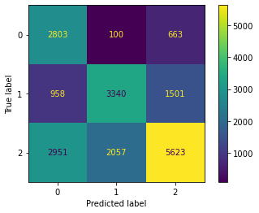

```python
plot_confusion_matrix(model1,xtest,ytest)
```

```python
print(classification_report(ytest,y_pred))
```

```
              precision    recall  f1-score   support

           0       0.42      0.79      0.55      3566
           1       0.61      0.58      0.59      5799
           2       0.72      0.53      0.61     10631

    accuracy                           0.59     19996
   macro avg       0.58      0.63      0.58     19996
weighted avg       0.63      0.59      0.59     19996
```

```python
from sklearn.model_selection import RandomizedSearchCV
```

```python
clf = RandomForestClassifier()  # Use the appropriate classifier for your multi-class problem
param_grid = {
    'n_estimators': [100, 200, 300],
    'max_depth': [5, 10, 15],
    'max_features': ['sqrt', 'log2']
    # Include other hyperparameters specific to your classifier
}
```

```python
random_search = RandomizedSearchCV(clf, param_grid, scoring='accuracy', cv=5)
random_search.fit(x_train, y_train)  # Replace X and y with your training data
```

```
RandomizedSearchCV(cv=5, estimator=RandomForestClassifier(),
                   param_distributions={'max_depth': [5, 10, 15],
                                        'max_features': ['sqrt', 'log2'],
                                        'n_estimators': [100, 200, 300]},
                   scoring='accuracy')
```

```python
from sklearn.metrics import classification_report

# Fit the model
model1= log_reg.fit(x_train,y_train)

# Generate predictions on the test set
y_pred= model1.predict(xtest)
y_pred

# Generate classification report
print(classification_report(ytest,y_pred))
```

```
              precision    recall  f1-score   support

           0       0.42      0.79      0.55      3566
           1       0.61      0.58      0.59      5799
           2       0.72      0.53      0.61     10631

    accuracy                           0.59     19996
   macro avg       0.58      0.63      0.58     19996
weighted avg       0.63      0.59      0.59     19996
```

Insight:

```python
from sklearn.metrics import roc_auc_score,roc_curve,plot_roc_curve
import matplotlib.pyplot as plt
```

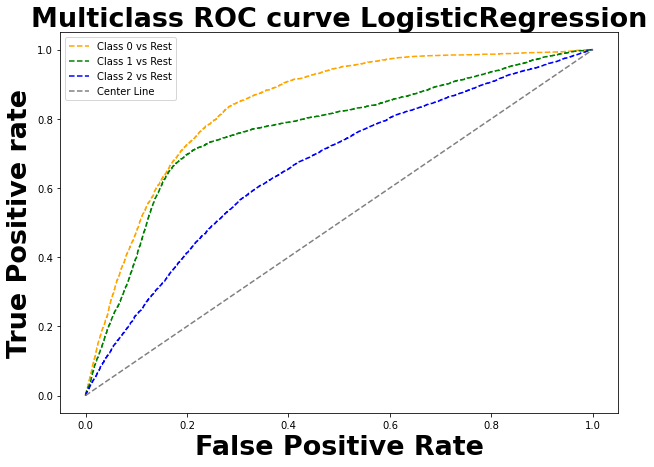

```python
import numpy as np
import matplotlib.pyplot as plt

ypredpropa = model1.predict_proba(xtest)
n_class = 3
fpr = {}
tpr = {}
thresh = {}

for i in range(n_class):
    fpr[i], tpr[i], thresh[i] = roc_curve(ytest, ypredpropa[:, i], pos_label=i)

# plotting
plt.figure(figsize=(10, 7))
plt.plot(fpr[0], tpr[0], linestyle="--", color="orange", label="Class 0 vs Rest")
plt.plot(fpr[1], tpr[1], linestyle="--", color="green", label="Class 1 vs Rest")
plt.plot(fpr[2], tpr[2], linestyle="--", color="blue", label="Class 2 vs Rest")

# Plot center line
plt.plot([0, 1], [0, 1], color="gray", linestyle="--", label="Center Line")

plt.title("Multiclass ROC curve LogisticRegression", size=27, fontweight="bold")
plt.xlabel("False Positive Rate", size=27, fontweight="bold")
plt.ylabel("True Positive rate", size=27, fontweight="bold")
plt.legend(loc="best")
plt.savefig("Multiclass ROC_pipe", dpi=300)
plt.show()
```

Insight:

[output not shown]

```python
from sklearn.metrics import roc_auc_score

y_pred_prob = model1.predict_proba(xtest)
roc_auc = roc_auc_score(ytest, y_pred_prob, multi_class='ovr')
print("ROC AUC:", roc_auc)
```

```
ROC AUC: 0.7563947865377215
```

# KNN WITH SUITABLE K

```python
from sklearn.neighbors import KNeighborsClassifier
```

```python
knn = KNeighborsClassifier()
```

```python
knn.fit(x_train,y_train)
y_pred = knn.predict(xtest)
```

```python
accuracy_score(ytest,y_pred)
```

```
0.8669233846769354
```

```python
confusion_matrix(ytest,y_pred)
```

```
array([[3389,    2,  175],
       [   7, 5499,  293],
       [ 940, 1244, 8447]], dtype=int64)
```

```
<sklearn.metrics._plot.confusion_matrix.ConfusionMatrixDisplay at 0x1e8eaa65cd0>
```

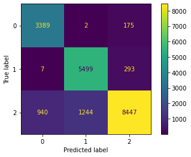

```python
plot_confusion_matrix(knn,xtest,ytest)
```

```python
from sklearn.metrics import plot_confusion_matrix,accuracy_score,precision_score,f1_score,roc_auc_score,classification_report,confusion_matrix
```

```python
confusion_matrix(ytest,y_pred)
```

```
array([[3389,    2,  175],
       [   7, 5499,  293],
       [ 940, 1244, 8447]], dtype=int64)
```

```python
print(classification_report(ytest,y_pred))
```

```
              precision    recall  f1-score   support

           0       0.78      0.95      0.86      3566
           1       0.82      0.95      0.88      5799
           2       0.95      0.79      0.86     10631

    accuracy                           0.87     19996
   macro avg       0.85      0.90      0.87     19996
weighted avg       0.88      0.87      0.87     19996
```

Insight:

```
The KNeighborsClassifier algorithm demonstrates strong performance with an accuracy of 87%. All classes exhibit high precision and recall, indicating accurate predictions. The F1-scores range from 0.86 to 0.88, highlighting a good balance between precision and recall. Overall, the algorithm achieves reliable classification results, with a macro average F1-score of 0.87.
```

```python
from sklearn.metrics import roc_auc_score,roc_curve,plot_roc_curve
import matplotlib.pyplot as plt
```

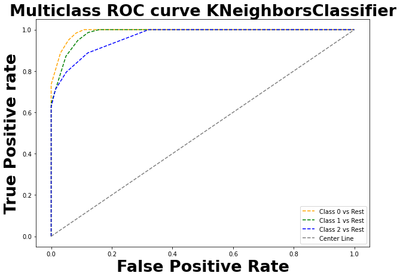

```python
import numpy as np
import matplotlib.pyplot as plt

ypredpropa = knn.predict_proba(xtest)
n_class = 3
fpr = {}
tpr = {}
thresh = {}

for i in range(n_class):
    fpr[i], tpr[i], thresh[i] = roc_curve(ytest, ypredpropa[:, i], pos_label=i)

# plotting
plt.figure(figsize=(10, 7))
plt.plot(fpr[0], tpr[0], linestyle="--", color="orange", label="Class 0 vs Rest")
plt.plot(fpr[1], tpr[1], linestyle="--", color="green", label="Class 1 vs Rest")
plt.plot(fpr[2], tpr[2], linestyle="--", color="blue", label="Class 2 vs Rest")

# Plot center line
plt.plot([0, 1], [0, 1], color="gray", linestyle="--", label="Center Line")

plt.title("Multiclass ROC curve KNeighborsClassifier", size=27, fontweight="bold")
plt.xlabel("False Positive Rate", size=27, fontweight="bold")
plt.ylabel("True Positive rate", size=27, fontweight="bold")
plt.legend(loc="best")
plt.savefig("Multiclass ROC_pipe", dpi=300)
plt.show()
```

Insight:

```python
from sklearn.metrics import roc_auc_score

y_pred_prob = knn.predict_proba(xtest)
roc_auc = roc_auc_score(ytest, y_pred_prob, multi_class='ovr')
print("ROC AUC:", roc_auc)
```

```
ROC AUC: 0.9793648613475859
```